# project part 2

```r
##So we load the data, and have a look at what the first few lines are like.
library(ggplot2)
data(ToothGrowth)
head(ToothGrowth)
```

```
##    len supp dose
## 1  4.2   VC  0.5
## 2 11.5   VC  0.5
## 3  7.3   VC  0.5
## 4  5.8   VC  0.5
## 5  6.4   VC  0.5
## 6 10.0   VC  0.5
```

```r
##Then we find the summary which is required.
summary(ToothGrowth)
```

```
##       len        supp         dose
##  Min.   : 4.20   OJ:30   Min.   :0.500
##  1st Qu.:13.07   VC:30   1st Qu.:0.500
##  Median :19.25           Median :1.000
##  Mean   :18.81           Mean   :1.167
##  3rd Qu.:25.27           3rd Qu.:2.000
##  Max.   :33.90           Max.   :2.000
```

We will then clean the data and look into the variables we need, using the point we are measuring to be the length of the teeth

```r
ToothGrowth$dose<-as.factor(ToothGrowth$dose)

MeanSupp = split(ToothGrowth$len, ToothGrowth$supp)
sapply(MeanSupp, mean)
```

```
##       OJ       VC
## 20.66333 16.96333
```

Then we have a look at the effect of the supplements on the tooth length

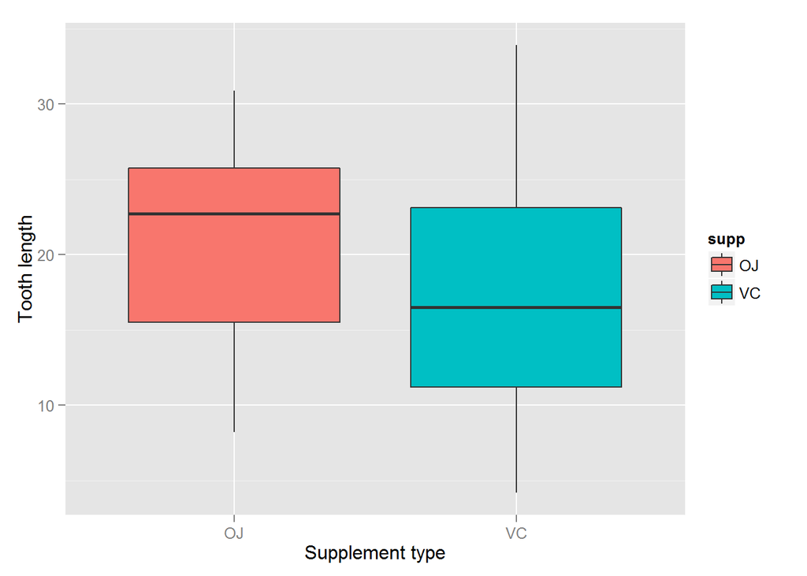

```r
ggplot(aes(x=supp, y=len), data=ToothGrowth) + geom_boxplot(aes(fill=supp))+
        xlab("Supplement type") +ylab("Tooth length")
```

```r
MeanDose = split(ToothGrowth$len, ToothGrowth$dose)
sapply(MeanDose, mean)
```

```
##    0.5      1      2
## 10.605 19.735 26.100
```

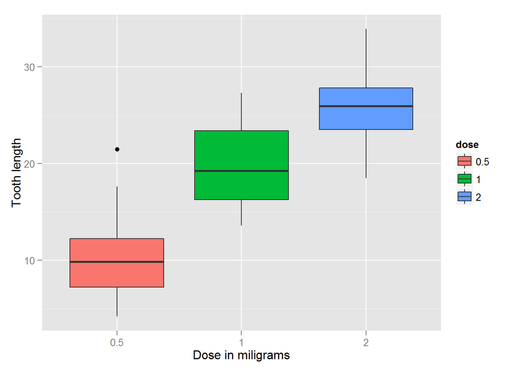

```r
ggplot(aes(x=dose, y=len), data=ToothGrowth) + geom_boxplot(aes(fill=dose)) +
        xlab("Dose in miligrams") +ylab("Tooth length")
```

From the plot, we can see that as the dose gets larger (to 2) the length of the teeth also gets larger - I wonder what other health effects this might have on the poor creatures.

```r
len<-ToothGrowth$len
supp<-ToothGrowth$supp
dose<-ToothGrowth$dose

sapply(MeanSupp, var)
```

```
##       OJ       VC
## 43.63344 68.32723
```

```r
t.test(len[supp=="OJ"], len[supp=="VC"], paired = FALSE, var.equal = FALSE)
```

```
##
##  Welch Two Sample t-test
##
## data:  len[supp == "OJ"] and len[supp == "VC"]
## t = 1.9153, df = 55.309, p-value = 0.06063
## alternative hypothesis: true difference in means is not equal to 0
## 95 percent confidence interval:
##  -0.1710156  7.5710156
## sample estimates:
## mean of x mean of y
##  20.66333  16.96333
```

The p-value is 6%, which is just slightly larger than the significant value of 5%, which means we can theoretically accept the null hypothesis, but should keep in mind that the confidence level or significant value is only a gauge and such a close fit might require more samples to lean towards a fairer analysis.

```r
t.test(len[dose==2], len[dose==1], paired = FALSE, var.equal = TRUE)
```

```
##
##  Two Sample t-test
##
## data:  len[dose == 2] and len[dose == 1]
## t = 4.9005, df = 38, p-value = 1.811e-05
## alternative hypothesis: true difference in means is not equal to 0
## 95 percent confidence interval:
##  3.735613 8.994387
## sample estimates:
## mean of x mean of y
##    26.100    19.735
```

The p-value of this test is small enough to be counted as zero, which is evidence to reject the null hypothesis. Which means that the change in Vitamin C dosage is conclusively related to the change in tooth length of guinea pigs.

Using the confidence level of 95%, we will assume that the type of supplements may not have significant impact on the tooth length of guinea pigs, but the increased dosage of Vitamin C has a real impact.